# Reddit r/realmadrid - relation between team performance and community behaviour

1. Introduction
2. Setup
3. Data Collection and Transformation
4. Exploratory Data Analysis
5. Inferential Statistics
6. Conclusion

## 1. Introduction

Aim with this project is to examine if there is a relationship between the behaviour of users of r/realmadrid and the actual results of the team's matches. The behaviour of community will be characterized by the frequency and sentiments of comments in the Real Madrid subreddit (r/realmadrid).

Real Madrid fans have one of the worst reputations when it comes to being overly reactive. Even after winning 3 Champions Leagues in a row, a defeat or draw brings out a lot of criticism and negative comments.

The strength of the relationship between user comments and team results can be compared with other teams to see if the Real Madrid fans are more reactive than other big teams.

There are a few anticipated problems:

- Reddit is just one environment where the Real Madrid fans interact. Arguably, it is one of the more balanced platforms, and fans are not as reactive as other platforms, say Facebook or Twitter.
- A lot of the overly negative comments (swearing certain players for example) are removed by the mods so the results will be biased.
- Reddit is also home to a lot of sarcastic comments and jokes which are not easily detectable by sentimentality analysis tools such as `TextBlob`

The data will be collected Pushshift API.

For each week, I will compute engagement metrics, sentiment metrics and also compute teams's performance metrics.

Enagement refers to how active the users are in the community - i.e. - whether they are posting submissions or comments on the subreddit.

Sentiment refers to the polarity of the comments made by the users. It ranges from negative (angry, depressed, disappointed, etc.) to positive (happy, relaxed, excited, elated, etc.)

Then, using statistical tests, I draw inferences on the variance in the sentiment and engagement for different team results. Using this analysis, I evaluate strength of these relationships (and in future plan to evaluate machine learning models for match result prediction based on the comments data).

## 2. Setup

```python
#! python3

# DATA COLLECTION AND TRANSFORMATION

# Official Reddit API
import praw

# Pushshift API for historical reddit data
from psaw import PushshiftAPI

# Unicode database lookup
import unicodedata

# Serialization into byte stream and deserialization into object
# Good for object storage as file
import pickle

# Database connection and querying
# For reading team results data from sport.db
import sqlite3

# For datetime data type
import datetime as dt

# A commonly used library for tabular data structures and analysis
import pandas as pd

# Mathematical operations
import numpy as np

# For finding index to insert data into in a sorted list
import bisect

# SENTIMENTALITY ANALYSIS
from textblob import TextBlob

# PLOTTING

import matplotlib
import matplotlib.pyplot as plt
import matplotlib.dates as mdates
import seaborn as sns
%matplotlib inline

# STATISTICAL ANALYSIS

# Statistical Testing
# fitting statistical model estimations and running statistical tests like ANOVA
# provides R like features, works with Panda and np arrays
import statsmodels.api as sm
import statsmodels.formula.api as smf
import statsmodels.stats as sms
# scientiific computing - commonly used algos and tasks like optimization, solving etc.
import scipy

# Other
from sklearn.model_selection import train_test_split
import os
```

## 3. Data Collection and Transformation

There are 2 main types of data that need to be collected - the match results and the submissions/comments from the team subreddit.

The final table structure we want is like this:

| week_finish | matches_played | performance_metric | performance_category | sentimentality_metric | engagement_metric |
| --- | --- | --- | --- | --- | --- |
| 2016-09-20 | 2 | 0.55 | Good | 0.08 | 400 |
| .. | .. | .. | .. | .. | .. |
| .. | .. | .. | .. | .. | .. |

### 3.1 Match Results

First, Real Madrids actual match results need to be collected. There are several ways to do this. One way would be to parse this info from the Post-Match threads on the subreddit of the team. However, the way I chose to do this is by using the community maintained open source football data from [OpenFootball](https://openfootball.github.io/). Essentially, I built a SQLite database using the `sportdb` command line tool and populated it using La Liga and UCL data from 2012 to 2018. Follow the instructions on how to use `sportdb` command line tool [here](https://github.com/sportdb/sport.db) and [here](https://github.com/openfootball/es-espana)

Once the `sport.db` database is built, it can be queried to extract required data. An initial dataframe with individual results data for each Real Madrid match can be created. Then, we need to transform it into a dataframe with the columns shown above.

```python
def get_team_match_results(team_key="madrid"):
    """
    Returns the dataframe containing all the results for team
    """
    conn = sqlite3.connect('sport.db')
    query_string = """
    SELECT `games`.`id`, `t1`.`key` AS `key1`,
    `t2`.`key` AS `key2`,
    `games`.`score1`, `games`.`score2`,
    `games`.`winner`, `games`.`play_at`
    FROM `games`
    INNER JOIN `teams` `t1`
    ON `games`.`team1_id` = `t1`.`id`
    INNER JOIN `teams` `t2`
    ON `games`.`team2_id` = `t2`.`id`
    WHERE `t1`.`key` = ?
    OR `t2`.`key` = ?
    ORDER BY `games`.`play_at` DESC
    LIMIT 1000;
    """
    return pd.read_sql_query(con=conn,sql=query_string, params=(team_key, team_key))

# Convert play_at column into a datetime type and make it index
def index_dataframe_correctly(dataframe, column="play_at"):
    date_time_series = pd.to_datetime(dataframe[column])
    dataframe[column] = date_time_series
    dataframe.set_index(column, inplace=True)

# Remove entries before a certain date
def remove_entries_before_date(df, ts=pd.Timestamp(2012, 9, 1)):
    _indexes_to_remove = []
    for _dt in df.index:
        if _dt < ts:
            _indexes_to_remove.append(_dt)
    df.drop(_indexes_to_remove, inplace=True)


# Helper functions
def match_won(home, winner):
    """Returns whether the subject team won"""
    if home:
        return winner==1
    else:
        return winner==2

def match_drawn(winner):
    """Returns whether the match was drawn"""
    return winner==0

def goals_conceded(home, score1, score2):
    """Return goals conceded by the subject team"""
    if not home:
        return score1
    else :
        return score2

def goals_scored(home, score1, score2):
    """Returns goals scored by the subject team"""
    return score1 + score2 - goals_conceded(home, score1, score2)

def performance_metric(home, won, drawn, scored, conceded):
    """Calculates a performance_metric based on the result and scoreline of the match"""
    metric = 0
    if won:
        metric += 0.4
    elif (not won and not drawn):
        metric -= 0.4
    metric += (scored-conceded) * 0.2
    if not home:
        metric += 0.05
    else:
        metric -= 0.05
    if metric>1 :
        return 1
    elif metric<-1:
        return -1
    return metric

def performance_category(perf_met):
    """Returns a performance_category based on a performance_metric value"""
    if perf_met < -0.1:
        return "Disaster"
    elif perf_met > 0.45:
        return "Good"
    else:
        return "Bad"

def add_derived_columns(df, team_key="madrid"):
    """
    Create additional columns for whether it was a home game, whether the team in question won, drew, how many goals they scored,
    how many they conceded and finally use all this information to calculate a performance metric
    """
    df["home"] = df["key1"].apply(lambda x: x==team_key)
    # np.vectorize returns array-like and takes inputs as array-likes instead of scalars
    df['won'] = np.vectorize(match_won)(df['home'], df['winner'])
    df['drawn'] = np.vectorize(match_drawn)(df['winner'])
    df['goals_scored'] = np.vectorize(goals_scored)(df['home'], df['score1'], df['score2'])
    df['goals_conceded'] = np.vectorize(goals_conceded)(df['home'], df['score1'], df['score2'])
    df['performance_metric'] = np.vectorize(performance_metric)(
        df['home'], df['won'], df['drawn'], df['goals_scored'], df['goals_conceded']
    )

def aggregate_by_week(raw_df):
    """
    Groups the matches by week and returns a dataframe with 3 columns:
    "matches_played", "performance_metric", "performance_category"
    """
    filtered_df = pd.DataFrame(raw_df.resample('W', convention='end').mean().performance_metric)
    filtered_df["matches_played"] = raw_df.resample('W', convention='end').count().id
    filtered_df.index.set_names(["week_finish"], inplace=True)
    filtered_df['performance_category'] = filtered_df['performance_metric'].apply(performance_category)
    return filtered_df

def transform_dataframe_to_desired(dataframe):
    """Returns a new transformed dataframe with new columns like performance_metric"""
    index_dataframe_correctly(dataframe)
    remove_entries_before_date(dataframe)
    add_derived_columns(dataframe)
    return aggregate_by_week(dataframe)

# It should be noted that most of these functions are changing the dataframe in place instead of creating a copy and returning it
```

Now we can execute the above functions to load and transform the data

```python
realmadrid_results_raw_df = get_team_match_results(team_key="madrid")
print("Initial raw dataframe")
display(realmadrid_results_raw_df.head())
df = transform_dataframe_to_desired(realmadrid_results_raw_df)
print("Intermediate dataframe")
display(realmadrid_results_raw_df.head())
print("Final dataframe")
display(df.head())
```

```
Initial raw dataframe
```

|  | id | key1 | key2 | score1 | score2 | winner | play_at |
| --- | --- | --- | --- | --- | --- | --- | --- |
| 0 | 17296 | madrid | liverpoolmontevideo | 3 | 1 | 1 | 2018-05-26 12:00:00 |
| 1 | 9839 | villareal | madrid | 2 | 2 | 0 | 2018-05-19 12:00:00 |
| 2 | 9830 | madrid | celta | 6 | 0 | 1 | 2018-05-12 12:00:00 |
| 3 | 9822 | sevilla | madrid | 3 | 2 | 1 | 2018-05-09 12:00:00 |
| 4 | 9818 | barcelona | madrid | 2 | 2 | 0 | 2018-05-06 12:00:00 |

```
Intermediate dataframe
```

| play_at | id | key1 | key2 | score1 | score2 | winner | home | won | drawn | goals_scored | goals_conceded | performance_metric |
| --- | --- | --- | --- | --- | --- | --- | --- | --- | --- | --- | --- | --- |
| 2018-05-26 12:00:00 | 17296 | madrid | liverpoolmontevideo | 3 | 1 | 1 | True | True | False | 3 | 1 | 0.75 |
| 2018-05-19 12:00:00 | 9839 | villareal | madrid | 2 | 2 | 0 | False | False | True | 2 | 2 | 0.05 |
| 2018-05-12 12:00:00 | 9830 | madrid | celta | 6 | 0 | 1 | True | True | False | 6 | 0 | 1.00 |
| 2018-05-09 12:00:00 | 9822 | sevilla | madrid | 3 | 2 | 1 | False | False | False | 2 | 3 | -0.55 |
| 2018-05-06 12:00:00 | 9818 | barcelona | madrid | 2 | 2 | 0 | False | False | True | 2 | 2 | 0.05 |

```
Final dataframe
```

| week_finish | performance_metric | matches_played | performance_category |
| --- | --- | --- | --- |
| 2012-09-02 | 0.95 | 1 | Good |
| 2012-09-09 | NaN | 0 | Bad |
| 2012-09-16 | -0.55 | 1 | Disaster |
| 2012-09-23 | 0.70 | 2 | Good |
| 2012-09-30 | 1.00 | 1 | Good |

### 3.2 Reddit comments data

Reddit comments data was collected using Pushshift API (psaw library). This allows access to historical data without HTTP Request limits imposed on the official Reddit PRAW library.

```python
# Reddit Agent Initialization
# Fill these details with your own Reddit account's

reddit = praw.Reddit(client_id='*********', \
                     client_secret='**************', \
                     user_agent='***********', \
                     username='******', \
                     password='********')
print("Reddit username:", reddit.user.me())
```

```
Reddit username: ******
```

```python
def get_submissions(subreddit="realmadrid", start_epoch=None, end_epoch=None):
    """
    Loads all submissions data (excluding comments) from specified subreddit and
    returns it in form of a list of PRAW submission objects
    """
    return list(PushshiftAPI(reddit).search_submissions(after=start_epoch,
                            before=end_epoch,
                            sort='score:desc',
                            subreddit=subreddit,
                            # filter=['created_utc', 'score', 'body'],
                            limit=50000))

def get_comments(subreddit="realmadrid", start_epoch=None, end_epoch=None):
    """
    Loads all comments data from specified subreddit and
    returns it in form of a list of dictionary objects with fields: created_utc, score, body
    """
    psaw_comments_list = list(PushshiftAPI().search_comments(after=start_epoch,
                            before=end_epoch,
                            sort='score:desc',
                            subreddit=subreddit,
                            filter=['created_utc', 'score', 'body'],
                            limit=900000))
    return [{'created_utc':x.created_utc, 'score':x.score, 'body':x.body} for x in psaw_comments_list]
```

```python
# Check if comments and submissions data has already been downloaded in the past
# and get it from local pckl file if so, otherwise download

start_epoch = int(dt.datetime(2012, 9, 1).timestamp())
end_epoch = int(dt.datetime(2018, 6, 10).timestamp())

if os.path.isfile("realmadrid_comments.pckl"):
    realmadrid_comments = pickle.load(open('realmadrid_comments.pckl', 'rb'))
else:
    realmadrid_comments = get_comments(subreddit="realmadrid", start_epoch=start_epoch, end_epoch=end_epoch)
    pickle.dump(realmadrid_comments, open( "realmadrid_comments.pckl", "wb"))

if os.path.isfile("realmadrid_submissions.pckl"):
    realmadrid_submissions = pickle.load(open('realmadrid_submissions.pckl', 'rb'))
else:
    realmadrid_submissions = get_submissions(subreddit="realmadrid", start_epoch=start_epoch, end_epoch=end_epoch)
    pickle.dump(realmadrid_submissions, open( "realmadrid_submissions.pckl", "wb"))

print("realmadrid_submissions length :", len(realmadrid_submissions))
print("realmadrid_comments length :", len(realmadrid_comments))
```

```
realmadrid_submissions length : 36654
realmadrid_comments length : 512775
```

Now we will add a column for engagement metric, which is just the total number of comments made in a week

```python
def add_engagement_metric(dataframe, submissions):
    dataframe["engagement_metric"] = 0
    eng_met_col_index = dataframe.columns.get_loc("engagement_metric")
    for submission in submissions:
        time_stamp = submission.created_utc
        score = submission.score
        _dt = pd.to_datetime(time_stamp, unit="s")
        week_index = bisect.bisect_left(dataframe.index, _dt)
        if week_index >= len(dataframe):
            continue
        engagement_metric = submission.num_comments
        dataframe.iat[week_index, eng_met_col_index] += engagement_metric

add_engagement_metric(df, realmadrid_submissions)
```

Similarly, we will add a column for sentimentality metric

```python
def compute_sentiment(s):
    """
    Returns the sentiment polarity of the comment body
    using textblob package
    input: string
    output: namedtuple of the form
    Sentiment(polarity, subjectivity). The polarity
    score is a float within the range [-1.0, 1.0].
    The subjectivity is a float within the range
    [0.0, 1.0] where 0.0 is very objective and 1.0
    is very subjective.
    """
    return TextBlob(s).sentiment

def get_comment_sentiment(comment):
    """
    Returns (polarity, weight) tuple
    """
    sentiment = compute_sentiment(comment['body'])
    polarity = sentiment.polarity
    subjectivity = sentiment.subjectivity
    # Return weight of 1 to make all comments weigh equally in sentimentality calculation
    # Can be changed in future
    return polarity, 1

def add_sentimentality_metric(dataframe, comments):
    """
    Adds a column for sentimality_metric to the dataframe.
    In place operation and returns nothing
    """

    dataframe["sentimentality_metric"] = 0.0

    # to hold the weighted no. of comments for the week, useful in calculating average
    dataframe["comments_n"] = 0
    sen_met_col_index = dataframe.columns.get_loc("sentimentality_metric")
    sen_n_col_index = dataframe.columns.get_loc("comments_n")

    for comment in comments:
        time_stamp = comment['created_utc']
        dt_time_stamp = pd.to_datetime(time_stamp, unit="s")
        week_index = bisect.bisect_left(dataframe.index, dt_time_stamp)
        if week_index >= len(dataframe):
            continue
        sentiment_metric, sentiment_n = get_comment_sentiment(comment)
        dataframe.iat[week_index, sen_met_col_index] += sentiment_metric
        dataframe.iat[week_index, sen_n_col_index] += sentiment_n

    normalize_sentimentality(dataframe)

def normalize_sentimentality(dataframe, sent_label="sentimentality_metric", n_label="comments_n"):
    """
    Converts the sentimentality_metric into an average instead of a sum figure
    """
    dataframe[sent_label] = dataframe[sent_label]/dataframe[n_label]
    dataframe.drop(inplace=True, columns=[n_label])

add_sentimentality_metric(df, realmadrid_comments)
```

```python
df.dropna(inplace=True)
# Store the dataframe into a pckl file for quick retrieval instead in future
pickle.dump(df, open( "df.pckl", "wb"))
df.head()
```

| week_finish | performance_metric | matches_played | performance_category | engagement_metric | sentimentality_metric |
| --- | --- | --- | --- | --- | --- |
| 2012-09-02 | 0.950 | 1 | Good | 14 | 0.138286 |
| 2012-09-16 | -0.550 | 1 | Disaster | 363 | 0.078575 |
| 2012-09-23 | 0.700 | 2 | Good | 414 | 0.098870 |
| 2012-09-30 | 1.000 | 1 | Good | 345 | 0.106030 |
| 2012-10-07 | 0.525 | 2 | Good | 237 | 0.095603 |

We can see that we have collected and transformed data into the desired format discussed at the beginning of this section

```python
# For loading the dataframe from the pckl file, use this cell
df = pickle.load(open('df.pckl', 'rb'))
```

## 4. Exploratory Data Analysis

Before we begin exploring the data, lets split the dataframe into training and testing dataset

```python
train_df, test_df = train_test_split(df, test_size = 0.15, random_state=42)
train_df.sort_index(inplace=True)
test_df.sort_index(inplace=True)
print("shape train_df", train_df.shape)
print("shape test_df", test_df.shape)
display(train_df.head(5))
```

```
shape train_df (175, 5)
shape test_df (31, 5)
```

[output not shown]

| week_finish | performance_metric | matches_played | performance_category | engagement_metric | sentimentality_metric |
| --- | --- | --- | --- | --- | --- |
| 2012-09-02 | 0.950 | 1 | Good | 14 | 0.138286 |
| 2012-09-16 | -0.550 | 1 | Disaster | 363 | 0.078575 |
| 2012-09-23 | 0.700 | 2 | Good | 414 | 0.098870 |
| 2012-09-30 | 1.000 | 1 | Good | 345 | 0.106030 |
| 2012-10-07 | 0.525 | 2 | Good | 237 | 0.095603 |

First we examine the distributions of all the columns

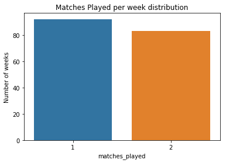

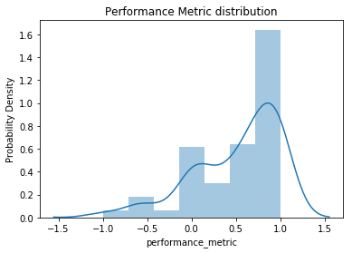

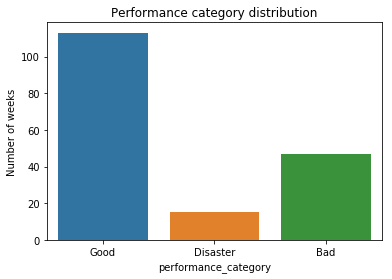

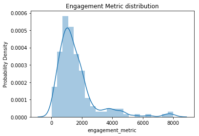

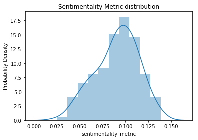

```python
sns.countplot(train_df["matches_played"])
plt.ylabel("Number of weeks")
plt.title("Matches Played per week distribution")
plt.show()

sns.distplot(train_df["performance_metric"], norm_hist=True)
plt.ylabel("Probability Density")
plt.title("Performance Metric distribution")
plt.show()

sns.countplot(train_df["performance_category"])
plt.ylabel("Number of weeks")
plt.title("Performance category distribution")
plt.show()

sns.distplot(train_df["engagement_metric"], norm_hist=True)
plt.ylabel("Probability Density")
plt.title("Engagement Metric distribution")
plt.show()

sns.distplot(train_df["sentimentality_metric"], norm_hist=True)
plt.ylabel("Probability Density")
plt.title("Sentimentality Metric distribution")
plt.show()
```

**Observations**

- The number of games in a week is either 1 or 2, which is as expected. The number of weeks with 2 games is almost same as number of weeks with 1 game, which is expected for a team like Real Madrid which regularly participates in La Liga, UCL, Copa del Rey, UEFA Super Cup, FIFA Club World Cup and Spanish Super Cup.
- The performance metric is heavily positive skewed, which is also expected for a team with a dominant team and history like Real Madrid.
- On the same note performance category also shows that majority of the times, Real Madrid performs very well
- Distribution of engagement metric shows that the number of comments typically is less than 2000 every week but it has reached to 8000 comments sometimes.
- The distribution of sentimality metric shows that the polarity of comments is positive on average every week. Note that this is possibly due to the fact that the positive comments and sarcastic jokes are more likely to be upvoted given the nature of Reddit community so it is expected that the sentiments are positive in general.
- The distribution of sentimentality metric is not as varied as I expected. A range of about 0.1 out of a maximum range of 2 is covered. This is partially because I am taking average over a large number of comments every week so typicallity prevails.

Now we can start looking at possible relations between these variables

**Engagement metric vs. Time**

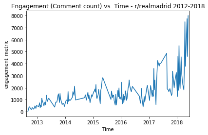

```python
def convert_to_days(date_time):
    """
    Returns number of days since 1 January 0001.
    Useful because this is how the data_time is represented in the matplotlib axis
    """
    return (date_time - dt.datetime(1,1,1)).days

def plot_engagement_vs_time(t1 = dt.datetime(2012, 8, 15), t2=dt.datetime(2018, 6, 15), col_name="engagement_metric", df=train_df):
    """
    Returns an axis with plot of engagement vs time for the specified period between t1 to t2
    """
    ax = sns.lineplot(x=df.index, y=df[col_name], data=df)
    ax.set_title("Engagement (Comment count) vs. Time - r/realmadrid " + str(t1.year) + "-" + str(t2.year))
    ax.set_xlabel("Time")
    ax.set_xlim(convert_to_days(t1), convert_to_days(t2))
    ax.xaxis.set_major_locator(mdates.YearLocator())
    ax.xaxis.set_major_formatter(mdates.DateFormatter('%Y'))
    return ax

plot_engagement_vs_time(t1=dt.datetime(2012, 8, 15), t2=dt.datetime(2018, 6, 15))
plt.show()
```

This is an interesting graph because it shows how the engagement has increased over time. The r/realmadrid community has really grown at a very appreciable rate throughout, and especially since 2017.

In order to make `engagement_metric` be dependent only on the team performance and not be dependent on the time, it should be transformed (equalized with respect to time).

This is done below by taking a rolling average of `engagement_metric` of last 24 matchweeks and calculating the ratio between each individual week's `enagement_metric` and the rolling average

[output not shown]

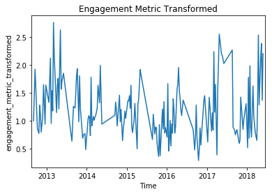

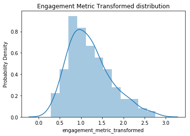

```python
def transform_engagement_metric(df, col_name="engagement_metric"):
    """
    Adds a column called 'engagement_metric_transformed' to the df
    """
    train_df["engagement_metric_transformed"] = train_df["engagement_metric"]/train_df["engagement_metric"].rolling(window=24, min_periods=1).mean()

def plot_transformed_graphs(df):
    plot_engagement_vs_time(t1=dt.datetime(2012, 8, 15), t2=dt.datetime(2018, 6, 15), col_name="engagement_metric_transformed")
    plt.title("Engagement Metric Transformed")
    plt.show()

    sns.distplot(df["engagement_metric_transformed"], norm_hist=True)
    plt.ylabel("Probability Density")
    plt.title("Engagement Metric Transformed distribution")
    plt.show()

transform_engagement_metric(train_df)
plot_transformed_graphs(train_df)
```

Clearly, this response is much better as overall it is a flatter profile over time. Now we can see if there is any relationship between `engagement_metric_transformed` and other metrics like `performance_category`, `performance_metric`, `matches_played` and `sentimentality_metric`

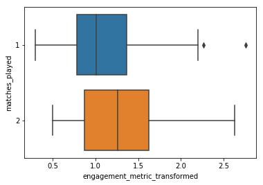

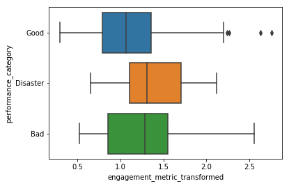

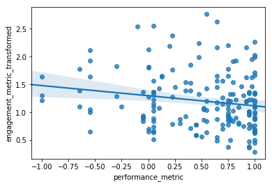

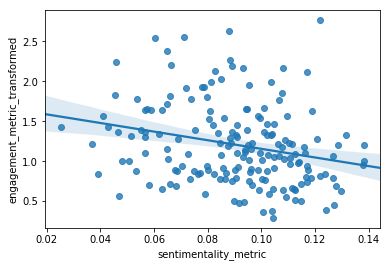

```python
sns.boxplot(y="matches_played", x="engagement_metric_transformed", data=train_df, orient='h')
plt.show()

sns.boxplot(y="performance_category", x="engagement_metric_transformed", data=train_df, orient='h')
plt.show()

sns.regplot(x='performance_metric', y='engagement_metric_transformed', data=train_df)
plt.show()

sns.regplot(x='sentimentality_metric', y='engagement_metric_transformed', data=train_df)
plt.show()
```

Similar scatter graphs can be produced for `sentimentality_metric` vs. other variables, as done below

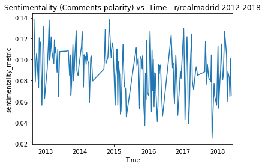

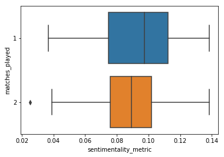

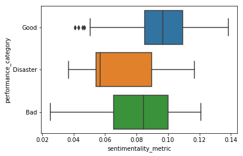

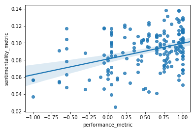

```python
def plot_sentimentality_vs_time(t1 = dt.datetime(2012, 8, 15), t2=dt.datetime(2018, 6, 15)):
    ax = sns.lineplot(x=train_df.index, y=train_df['sentimentality_metric'], data=train_df)
    ax.set_title("Sentimentality (Comments polarity) vs. Time - r/realmadrid " + str(t1.year) + "-" + str(t2.year))
    ax.set_xlabel("Time")
    ax.set_xlim(convert_to_days(t1), convert_to_days(t2))
    ax.xaxis.set_major_locator(mdates.YearLocator())
    ax.xaxis.set_major_formatter(mdates.DateFormatter('%Y'))
    return ax

plot_sentimentality_vs_time(t1=dt.datetime(2012, 8, 15), t2=dt.datetime(2018, 6, 15))
plt.show()

sns.boxplot(y="matches_played", x="sentimentality_metric", data=train_df, orient='h')
plt.show()

sns.boxplot(y="performance_category", x="sentimentality_metric", data=train_df, orient='h')
plt.show()

sns.regplot(x='performance_metric', y='sentimentality_metric', data=train_df)
plt.show()
```

**Observations**:

- The relations which seem worth exploring further are `sentimentality` vs. `performance` and `engagement` vs `performance`
- There is also visible relation between `matches_played` and `engagement` which is trivial
- There is also a visible relation between `sentimality` and `engagement` which is most likely not a direct relation but instead an indirect relation as both depend on `performance`

To reiterate, below is shown an overview of the correlations between different variables :

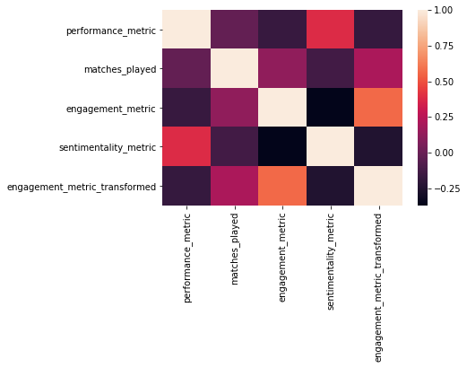

```python
train_corr = train_df.corr()
# fig = plt.figure(figsize=(6,6))
sns.heatmap(train_corr,xticklabels=True, yticklabels=True)
```

## 5. Inferential Statistics

In this hypothesis, I will analyze the statistical significance of the dependence of engagement metric and sentiments metric on performance metric.

The statistical test that best suits this scenario is the 1-way analysis of variance (ANOVA) test. Note that I am running 2 different ANOVA tests, one for engagement metric and one for sentiments metric

Test 1

**Null hypothesis:** The mean sentiment metric is independent of performance category

**Alternative hypothesis:** Mean sentiment metric is dependent of the performance category

Test 2

**Null hypothesis:** The mean engagement metric is independent of performance category

**Alternative hypothesis:** Mean engagement metric is dependent of the performance category

#### Checking for conditions of ANOVA test - the groups need to be normally distributed (same requirement for unpaired T-test)

- **Independence**: The observations should be independent within and across groups. The matches took separately so they can be considered independent events. We ignore that the oppositions change in strength and other factors.
- **Normality**: The data within each group should be nearly normal. Based on the figure below, none of the distributions seem to have exteme skewness.
- **Variability**: Variance also needs to be same across each group

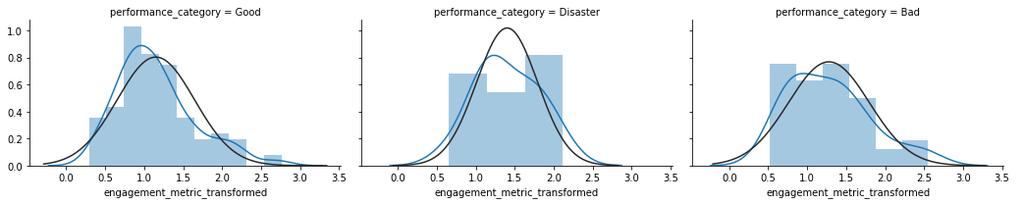

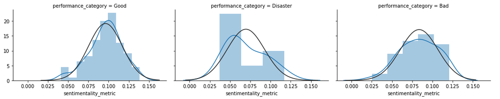

```python
grid = sns.FacetGrid(train_df, col='performance_category', height=3, aspect=1.6,)
grid.map(sns.distplot, 'engagement_metric_transformed', norm_hist=True, fit=scipy.stats.norm)
grid.add_legend();
plt.show()

grid = sns.FacetGrid(train_df, col='performance_category', height=3, aspect=1.6,)
grid.map(sns.distplot, 'sentimentality_metric', norm_hist=True, fit=scipy.stats.norm)
grid.add_legend();
plt.show()
```

From the KDE fit and the normal fit on the histograms above, we can say that the distributions are roughly normally distributed and we can apply ANOVA and t-tests

```python
print("t-test results for engagement_metric_transformed")
print(sms.weightstats.ttest_ind(
    x1=train_df[train_df['performance_category']=='Good']['engagement_metric_transformed'],
    x2=train_df[train_df['performance_category']!='Good']['engagement_metric_transformed'],
))
print()

print("t-test results for sentimentality_metric")
print(sms.weightstats.ttest_ind(
    x1=train_df[train_df['performance_category']=='Good']['sentimentality_metric'],
    x2=train_df[train_df['performance_category']!='Good']['sentimentality_metric'],
))
print()

def anova_test(df, dependent_var):
    mod = smf.ols(dependent_var + ' ~ C(performance_category)', data=df).fit()
    return(sm.stats.anova_lm(mod, typ=2))

print("engagement_metric_transformed vs performance_category - ANOVA test")
display(anova_test(train_df, 'engagement_metric_transformed'))
print("sentimentality _metric vs performance_category ANOVA test")
display(anova_test(train_df, 'sentimentality_metric'))
```

```
t-test results for engagement_metric_transformed
(-2.022596546339705, 0.04465473390312458, 173.0)

t-test results for sentimentality_metric
(4.576186875313553, 9.00661580291165e-06, 173.0)

engagement_metric_transformed vs performance_category - ANOVA test
```

|  | sum_sq | df | F | PR(>F) |
| --- | --- | --- | --- | --- |
| C(performance_category) | 1.194596 | 2.0 | 2.393033 | 0.094388 |
| Residual | 42.930981 | 172.0 | NaN | NaN |

```
sentimentality _metric vs performance_category ANOVA test
```

|  | sum_sq | df | F | PR(>F) |
| --- | --- | --- | --- | --- |
| C(performance_category) | 0.012467 | 2.0 | 13.010042 | 0.000005 |
| Residual | 0.082407 | 172.0 | NaN | NaN |

The p-value for ANOVA test on `engagement_metric_transformed` is **9%** which is above the accepted standard of 5%. This means the null hypothesis can not be rejected, and the relationship between `engagement_metric_transformed` and `performance_category` may just be by chance.

On the other hand, the p-value for ANOVA test on `sentimentality_metric` is just **0.0005%** which is well below the accepted standards of 5% or 1%. This means the null hypothesis can be rejected, and the relationship between `sentimentality_metric` and `performance_category` is **statistically significant**.

## 6. Conclusion

The initial idea behind this study was to see if the user behaviour of community changes with the Real Madrid's results on the field. A statistically significant relationship was observed between the teams performance metrics and the community's sentimentality metrics. Similar relationship was also observed for engagement metrics but we cannot conclude if that is statistically significant, we need more data.

We learnt that community on r/realmadrid is reactive to team results and this is reflected in the polarity of the comments they make. Thus there might be truth to the story that Real Madrid fans are very easily disappointed and hence 'spoiled'.

In order to continue this study, data can be collected from other social media like tweets and facebook comments. It should also be noted that sentimentality analysis has certain limitations if you do not create your machine learning model for the specific context (which in this case was football comments). Using a generic sentiment calculator from TextBlob package is not best (limitations of TextBlob in understanding football talk, reddit jokes, sarcasm etc.).

Coming in future:

- Implementation of a Machine Learning classifier which can predict the `performance_category` based on sentiment and engagement metrics
- Similar analysis done on other teams - FC Barcelona, Manchester United and Liverpool FC and compared with Real Madrid

Please contact me (Ankur Sharma) on ankur underscore sharma 309 at yahoo dot com for questions or suggestions. Thanks for reading!